## S2 Statistika Terapan — FMIPA Universitas Padjadjaran

Coaching Riset • Pendampingan proposal dan penguatan metodologi Pascasarjana Statistika

COACHING SESSION 4 • PRA-SUR

# Menajamkan Progres Proposal Tesis Menuju Seminar Usulan Riset

Empat mahasiswa mempresentasikan perkembangan proposal tesis dan mendiskusikan penguatan substansi, metodologi, serta kesiapan penelitian dalam sesi coaching tatap muka.

📅 Sabtu, 5 September 2026 📍 Departemen Statistika FMIPA Unpad 👥 4 Mahasiswa

**Jatinangor, 5 September 2026** — Program Studi S2 Statistika Terapan FMIPA Universitas Padjadjaran kembali menyelenggarakan **Coaching Session 4** secara luring di Gedung Departemen Statistika FMIPA Unpad. Sesi kali ini berfokus pada pembahasan **progres proposal tesis mahasiswa pada tahap Pra-SUR**.

Coaching diikuti oleh empat mahasiswa dengan topik penelitian yang mencakup pemodelan Bayesian, machine learning untuk peramalan, pemodelan hybrid, serta analisis spatio-temporal. Diskusi berlangsung sangat produktif dan diarahkan untuk membantu mahasiswa menajamkan pertanyaan penelitian, memperkuat argumentasi metodologis, serta memastikan kesiapan data dan strategi analisis sebelum memasuki tahapan Seminar Usulan Riset (SUR).

## Empat Proposal yang Dibahas

PRA-SUR

### Auro Aurellia Simbolon

**Pemodelan Probabilitas Gagal Bayar Pinjaman Online Menggunakan Bayesian Generalized Additive Model dengan Inferensi Integrated Nested Laplace Approximation.**

PRA-SUR

### Fellita Odelia Wibowo

**Model Peramalan Harga Harian Gabah Kering Panen (GKP) di Tingkat Petani Menggunakan XGBoost dengan Prediction Interval Berbasis EnbPI.**

PRA-SUR

### Hanifah Khairunnisa

**Model Hybrid Hidden Markov Model–XGBoost untuk Prediksi Universal Thermal Climate Index melalui Ekstraksi Latent Thermal Regime.**

PRA-SUR

### Salwa Azzah Imtiyaz

**Pemetaan Risiko Relatif Gempa Bumi pada Wilayah Sekitar Sesar Lembang Menggunakan Model Bayesian Hierarchical Spatio-Temporal.**

**Fokus coaching**

- mengevaluasi konsistensi antara masalah penelitian, tujuan, data, dan metode;
- menajamkan kontribusi ilmiah dan kebaruan setiap proposal;
- memastikan model statistik atau machine learning yang dipilih sesuai dengan karakteristik data;
- menyiapkan strategi evaluasi model, interpretasi hasil, serta rencana analisis yang dapat dipertanggungjawabkan.

**Target berikutnya**

Setiap mahasiswa diharapkan menindaklanjuti hasil diskusi melalui penyempurnaan proposal, penguatan landasan metodologi, dan pemantapan rancangan analisis sebagai persiapan menuju SUR.

“Coaching bukan sekadar memeriksa progres, tetapi memastikan setiap keputusan metodologis memiliki alasan ilmiah yang kuat dan benar-benar menjawab pertanyaan penelitian.”

## Dokumentasi Kegiatan

[figure not shown]

Diskusi progres proposal tesis dalam Coaching Session 4.

[figure not shown]

Mahasiswa mendiskusikan aspek metodologi dan pengembangan proposal.

[figure not shown]

Suasana coaching tatap muka di Departemen Statistika FMIPA Unpad.

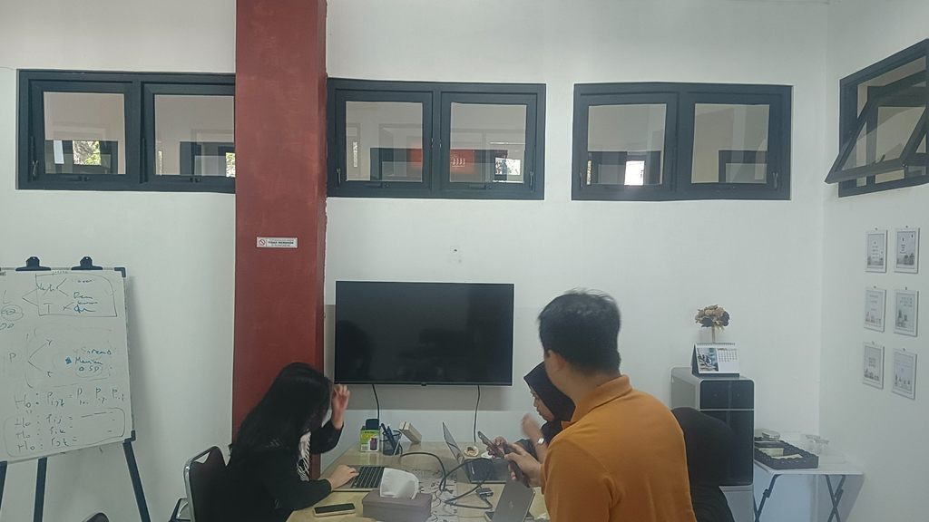

Sesi pendampingan dan diskusi proposal berlangsung secara intensif.

[figure not shown]

Pembahasan proposal tesis dan kesiapan menuju Seminar Usulan Riset (SUR).

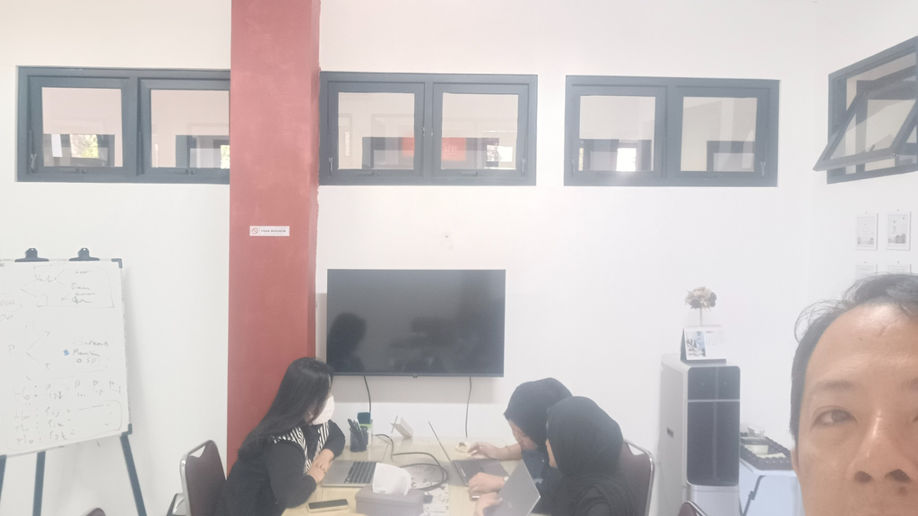

Dokumentasi kegiatan Coaching Session 4, Sabtu 5 September 2026.

Pelaksanaan secara tatap muka membuat diskusi berlangsung lebih intensif dan interaktif. Setiap proposal memperoleh ruang untuk dibedah dari sisi substansi dan metodologi, sehingga mahasiswa tidak hanya berfokus pada penggunaan metode yang canggih, tetapi juga pada **ketepatan metode terhadap masalah penelitian**.

Melalui Coaching Session 4 ini, Program Studi S2 Statistika Terapan FMIPA Unpad terus mendorong budaya riset yang kritis, kolaboratif, dan berorientasi pada kualitas. Pendampingan berkala diharapkan dapat membantu mahasiswa bergerak lebih terarah dari penyusunan proposal menuju penelitian tesis yang kuat secara metodologis dan relevan secara substantif.